# Sensitivity of song diversification and evolution inference

Beatriz Willink

2021-04-24

Here we look at the effects of alignment strategies, clock models, fossil records and sampling on diversification parameters, as well as the effects of alignment strategies on the parameters of models of song evolution.

First, load the packages that we will need.

```r
x <-
  c(
    "tidyr",
    "ggplot2",
    "viridis",
    "coda"
    )

lapply(x, function(y) {
  # check if installed, if not install
  if (!y %in% installed.packages()[, "Package"])
    install.packages(y)

  # load package
  try(require(y, character.only = T), silent = T)
})
```

And create some useful variables

```r
# directory of output files
out_fp <- "../output/most_recent_revbayes_models/"

# all the different factors and their levels
lek <- c("BR1", "CCE", "HC1", "SUR", "TR1")
aln <- c("all.equal", "optimal", "prank")
record <- c("old", "new", "no.fossils")
sampling <- c("all", "early")
clock <- c("global", "Uexp")

# colours and labels for figures below
aln_cols <- viridis(3,direction = -1)
aln_labs <- c("MAFFT-agnostic", "MAFFT-optimal", "PRANK-TN93")

clock_cols <- viridis(2,direction = -1, begin = 0, end = 0.4)
clock_labs <- c("fixed", "relaxed")

record_cols <- viridis(3,direction = 1, begin = 0.7, end = 1)
record_labs <- c("old gapped", "recent complete", "no historical")

sampling_cols <- viridis(3,direction = 1, begin = 0.5, end = 0.8)
sampling_labs <- c("all historical", "earliest record")
```

# Diversification rates and origin times

## Alignment strategy

To compare among alignments, we will focus on the results under a relaxed clock model, sampling all historical records (including identical songs in consecutive years) and the entire historical record, even if very gapped.

First, we select and merge output files

```r
file.ls <- list.files(path=out_fp,pattern=paste0(glob2rx("*all_*Uexp*"),"_[0-9]{6}.log"))

dat_com <- data.frame()
for (i in lek){
  if (i == "BR1" | i == "TR1" )
  for (j in aln) {
    tmp_file <- grep(pattern = paste(i,j,"new", sep = "_"), file.ls)
    tmp_data <- read.table(paste0(out_fp,file.ls[tmp_file]), header = T)
    tmp_data$lek <- i
    tmp_data$aln <- j
    br_rates <- grep("branch_rates.", colnames(tmp_data))
    tmp_data <- tmp_data[,-br_rates]
    dat_com <- rbind(dat_com, tmp_data)
  } else {
    for (j in aln) {
    tmp_file <- grep(pattern = paste(i,j,"old", sep = "_"), file.ls)
    tmp_data <- read.table(paste0(out_fp,file.ls[tmp_file]), header = T)
    tmp_data$lek <- i
    tmp_data$aln <- j
    br_rates <- grep("branch_rates.", colnames(tmp_data))
    tmp_data <- tmp_data[,-br_rates]
    dat_com <- rbind(dat_com, tmp_data)
    }
  }
}
```

We plot diversification parameters by lek and alignment.

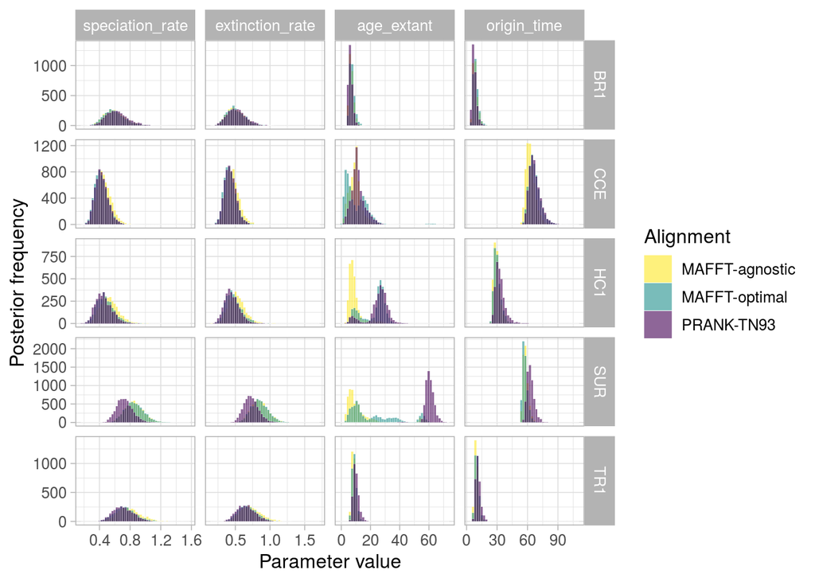

```r
# what are the parameters of interest?
div_pars <- c("speciation_rate", "extinction_rate", "age_extant", "origin_time")

# subset the data
plot_dat <- dat_com[,c("Iteration","lek", "aln", div_pars)]

# convert to long
plot_dat <- pivot_longer(plot_dat, cols = all_of(div_pars), names_to = "par" )

# reorder parameters
plot_dat$par_s = factor(plot_dat$par, levels = div_pars)

# plot
p_div_s_aln <- ggplot(data = plot_dat, aes(x = value, fill = aln)) +
  geom_histogram(position = "identity", bins = 50, colour = "white", alpha = 0.6, size =0.05) +
  facet_grid(rows = vars(lek), cols = vars(par_s), scales = "free") +
  theme_light(base_size = 12) +
  scale_fill_manual(values = aln_cols, labels = aln_labs) +
  labs(x = "Parameter value", y = "Posterior frequency", fill = "Alignment")
p_div_s_aln
```

We might want to quantify sensitivity to the alignment strategy. We can see how much of the posterior distribution of a parameter under a “query” alignment falls outside the 95% HPD interval of a “target” alignment. A higher non-overlap means the alignments produce different results. If query A falls within target B, but a lot of query B falls outside target A, then the alignment B produces a broader (more uncertain) posterior than alignment A.

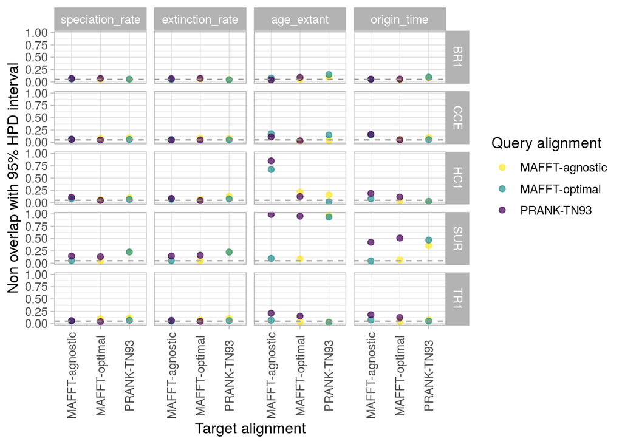

## Clock model

Are diversification parameters sensitive to the clock model?

### For PRANK

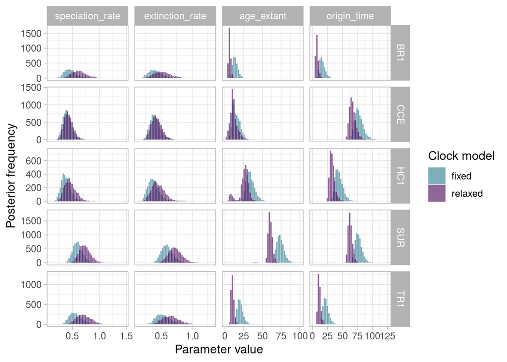

```r
file.ls <- list.files(path=out_fp,pattern=paste0(glob2rx("*prank*all*_*"),"[0-9]{6}.log"))

dat_prank_clock <- data.frame()
for (i in lek){
  if (i == "BR1" | i == "TR1" )
  for (j in clock) {
    tmp_file <- grep(pattern = paste(i,"prank","new","all",j, sep = "_"), file.ls)
    tmp_data <- read.table(paste0(out_fp,file.ls[tmp_file]), header = T)
    tmp_data <- tmp_data[,c("Iteration",div_pars)]
    tmp_data$lek <- i
    tmp_data$clock <- j
      dat_prank_clock <- rbind(dat_prank_clock, tmp_data)
  } else {
    for (j in clock) {
    tmp_file <- grep(pattern = paste(i,"prank","old","all",j, sep = "_"), file.ls)
    tmp_data <- read.table(paste0(out_fp,file.ls[tmp_file]), header = T)
    tmp_data <- tmp_data[,c("Iteration", div_pars)]
    tmp_data$lek <- i
    tmp_data$clock <- j
    dat_prank_clock <- rbind(dat_prank_clock, tmp_data)
    }
  }
}

plot_dat <- dat_prank_clock[,c("Iteration","lek", "clock", div_pars)]
plot_dat <- pivot_longer(plot_dat, cols = all_of(div_pars), names_to = "par" )

plot_dat$par_s = factor(plot_dat$par, levels = div_pars)

p_div_h_clock_prank <- ggplot(data = plot_dat, aes(x = value, fill = clock)) +
  geom_histogram(position = "identity", bins = 50, colour = "white", alpha = 0.6, size =0.05) +
  facet_grid(rows = vars(lek), cols = vars(par_s), scales = "free") +
  theme_light(base_size = 12) +
  scale_fill_manual(values = clock_cols, labels = clock_labs) +
  labs(x = "Parameter value", y = "Posterior frequency", fill = "Clock model")

p_div_h_clock_prank
```

### For MAFFT-optimal

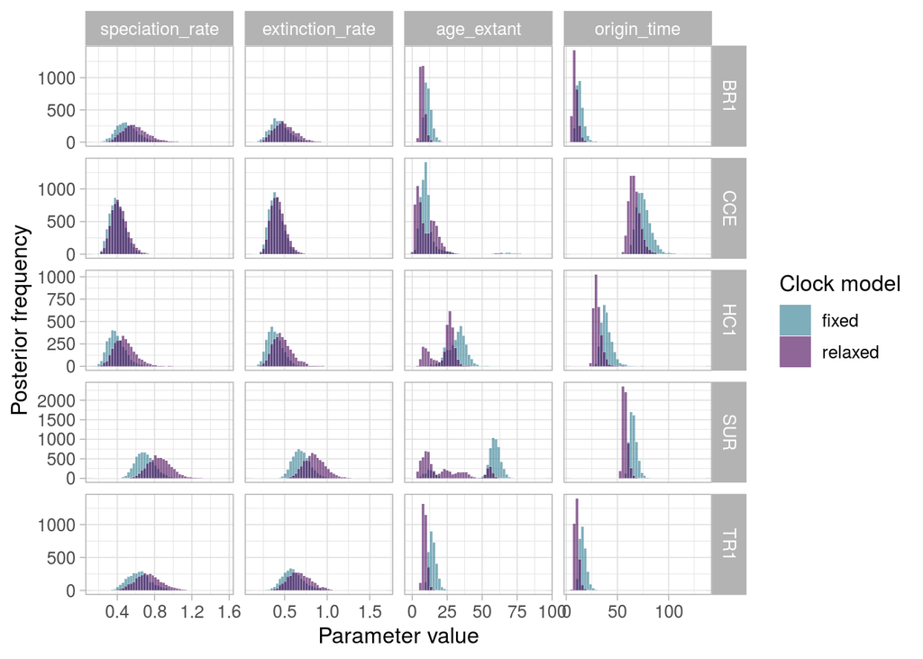

```r
file.ls <- list.files(path=out_fp,pattern=paste0(glob2rx("*optimal*all*_*"),"[0-9]{6}.log"))

dat_optimal_clock <- data.frame()
for (i in lek){
  if (i == "BR1" | i == "TR1" )
  for (j in clock) {
    tmp_file <- grep(pattern = paste(i,"optimal","new","all",j, sep = "_"), file.ls)
    tmp_data <- read.table(paste0(out_fp,file.ls[tmp_file]), header = T)
    tmp_data <- tmp_data[,c("Iteration",div_pars)]
    tmp_data$lek <- i
    tmp_data$clock <- j
      dat_optimal_clock <- rbind(dat_optimal_clock, tmp_data)
  } else {
    for (j in clock) {
    tmp_file <- grep(pattern = paste(i,"optimal","old","all",j, sep = "_"), file.ls)
    tmp_data <- read.table(paste0(out_fp,file.ls[tmp_file]), header = T)
    tmp_data <- tmp_data[,c("Iteration", div_pars)]
    tmp_data$lek <- i
    tmp_data$clock <- j
    dat_optimal_clock <- rbind(dat_optimal_clock, tmp_data)
    }
  }
}

plot_dat <- dat_optimal_clock[,c("Iteration","lek", "clock", div_pars)]
plot_dat <- pivot_longer(plot_dat, cols = all_of(div_pars), names_to = "par" )

plot_dat$par_s = factor(plot_dat$par, levels = div_pars)

p_div_h_clock_optimal <- ggplot(data = plot_dat, aes(x = value, fill = clock)) +
  geom_histogram(position = "identity", bins = 50, colour = "white", alpha = 0.6, size =0.05) +
  facet_grid(rows = vars(lek), cols = vars(par_s), scales = "free") +
  theme_light(base_size = 12) +
  scale_fill_manual(values = clock_cols, labels = clock_labs) +
  labs(x = "Parameter value", y = "Posterior frequency", fill = "Clock model")

p_div_h_clock_optimal
```

### For MAFFT-agnostic

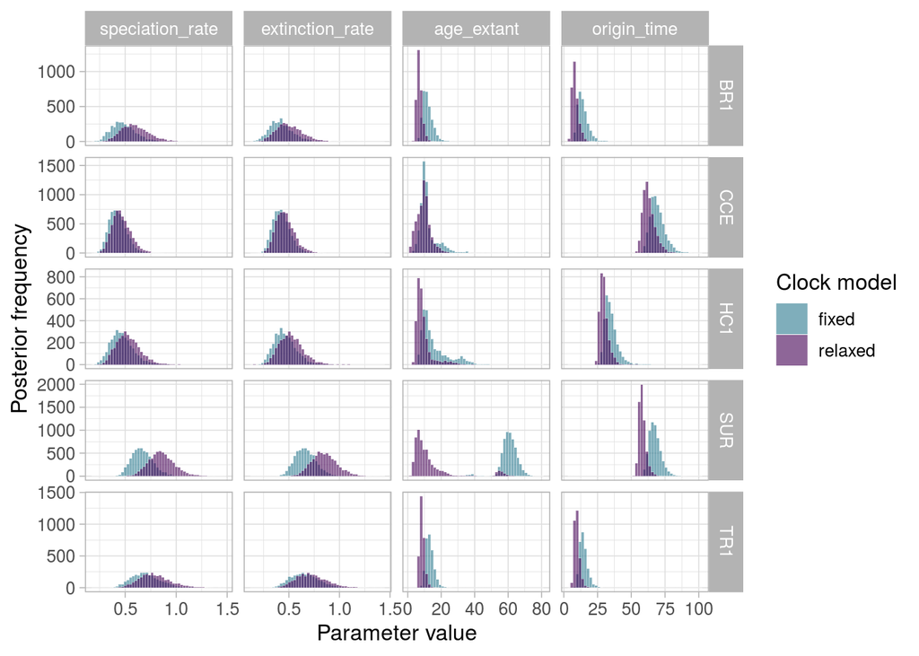

```r
file.ls <- list.files(path=out_fp,pattern=paste0(glob2rx("*all.equal*all*_*"),"[0-9]{6}.log"))

dat_all.equal_clock <- data.frame()
for (i in lek){
  if (i == "BR1" | i == "TR1" )
  for (j in clock) {
    tmp_file <- grep(pattern = paste(i,"all.equal","new","all",j, sep = "_"), file.ls)
    tmp_data <- read.table(paste0(out_fp,file.ls[tmp_file]), header = T)
    tmp_data <- tmp_data[,c("Iteration",div_pars)]
    tmp_data$lek <- i
    tmp_data$clock <- j
      dat_all.equal_clock <- rbind(dat_all.equal_clock, tmp_data)
  } else {
    for (j in clock) {
    tmp_file <- grep(pattern = paste(i,"all.equal","old","all",j, sep = "_"), file.ls)
    tmp_data <- read.table(paste0(out_fp,file.ls[tmp_file]), header = T)
    tmp_data <- tmp_data[,c("Iteration", div_pars)]
    tmp_data$lek <- i
    tmp_data$clock <- j
    dat_all.equal_clock <- rbind(dat_all.equal_clock, tmp_data)
    }
  }
}

plot_dat <- dat_all.equal_clock[,c("Iteration","lek", "clock", div_pars)]
plot_dat <- pivot_longer(plot_dat, cols = all_of(div_pars), names_to = "par" )

plot_dat$par_s = factor(plot_dat$par, levels = div_pars)

p_div_h_clock_all.equal <- ggplot(data = plot_dat, aes(x = value, fill = clock)) +
  geom_histogram(position = "identity", bins = 50, colour = "white", alpha = 0.6, size =0.05) +
  facet_grid(rows = vars(lek), cols = vars(par_s), scales = "free") +
  theme_light(base_size = 12) +
  scale_fill_manual(values = clock_cols, labels = clock_labs) +
  labs(x = "Parameter value", y = "Posterior frequency", fill = "Clock model")
p_div_h_clock_all.equal
```

## Use of the historical record

Are diversification parameters sensitive to a gappy historical record? What about ignoring historical songs (fossils) altogether?

### For PRANK

Assuming a relaxed clock and sampling all fossil records We can only use CCE HC1 and SUR for new vs old and BR1 TR1 and SUR for fossils vs no fossils

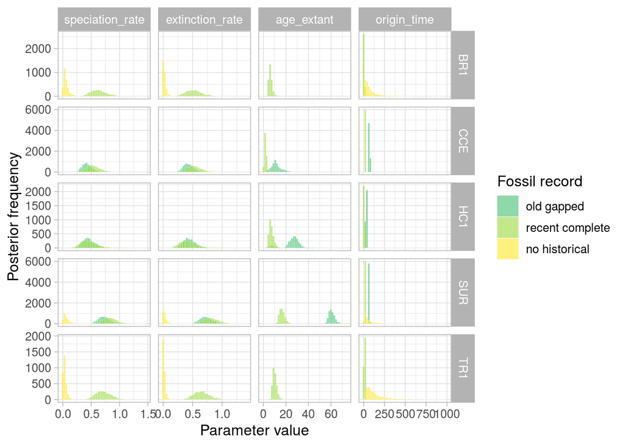

```r
file.ls <- list.files(path=out_fp,pattern=paste0(glob2rx("*prank*all*Uexp_*"),"[0-9]{6}.log","|",glob2rx("*prank*full.process*Uexp_*"),"[0-9]{6}.log"))

dat_prank_record <- data.frame()
for (i in lek) {
  if (i == "SUR") {
    for (j in record) {
      tmp_file <-
        grep(pattern = paste(i, "prank", j , sep = "_"), file.ls)
      tmp_data <-
        read.table(paste0(out_fp, file.ls[tmp_file]), header = T)
      if (j == "no.fossils") {
        tmp_data$age_extant <- NA
      }
      tmp_data <- tmp_data[, c("Iteration", div_pars)]
      tmp_data$lek <- i
      tmp_data$record <- j
      dat_prank_record <- rbind(dat_prank_record, tmp_data)
    }
  } else {
    if (i == "BR1" | i == "TR1") {
      for (j in record[2:3]) {
        tmp_file <-
          grep(pattern = paste(i, "prank", j , sep = "_"), file.ls)
        tmp_data <-
          read.table(paste0(out_fp, file.ls[tmp_file]), header = T)
        if (j == "no.fossils") {
          tmp_data$age_extant <- NA
        }
        tmp_data <- tmp_data[, c("Iteration", div_pars)]
        tmp_data$lek <- i
        tmp_data$record <- j
        dat_prank_record <- rbind(dat_prank_record, tmp_data)
      }
    } else {
      for (j in record[1:2]) {
        tmp_file <-
          grep(pattern = paste(i, "prank", j , sep = "_"), file.ls)
        tmp_data <-
          read.table(paste0(out_fp, file.ls[tmp_file]), header = T)
        tmp_data <- tmp_data[, c("Iteration", div_pars)]
        tmp_data$lek <- i
        tmp_data$record <- j
        dat_prank_record <- rbind(dat_prank_record, tmp_data)
      }
    }
  }
}

plot_dat <- dat_prank_record[,c("Iteration","lek", "record", div_pars)]
plot_dat <- pivot_longer(plot_dat, cols = all_of(div_pars), names_to = "par" )

plot_dat$par_s = factor(plot_dat$par, levels = div_pars)
plot_dat$record = factor(plot_dat$record, levels = c("old", "new", "no.fossils"))

p_div_h_record_prank <- ggplot(data = plot_dat, aes(x = value, fill = record)) +
  geom_histogram(position = "identity", bins = 50, colour = "white", alpha = 0.6, size =0.05) +
  facet_grid(rows = vars(lek), cols = vars(par_s), scales = "free") +
  theme_light(base_size = 12) +
  scale_fill_manual(values = record_cols, labels = record_labs) +
  labs(x = "Parameter value", y = "Posterior frequency", fill = "Fossil record")

p_div_h_record_prank
```